# compile-regional-data

#### Steelhead

Steelhead trout in the Fraser are monitored by the Province in at least 10 different streams, but these data are not readily available. Relatively reliable estimates of steelhead spawner abundance are available at the CU-level for interior Fraser steelhead from the Thompson Summer CU (monitored at the Thompson River) and Mid Fraser Summer CU (primarily monitored at the Chilcotin River; data in the [Pacific Salmon Explorer](https://salmonexplorer.ca)). We used the sum of CU-level spawner abundance for these two CUs as an index of Fraser steelhead abundance. We note that this approach does not include more coastal populations, such as the Lower Fraser Summer steelhead monitored in the Coquihalla River or Boundary Bay Winter steelhead, which may not have declined to the same extent over the past decade. However, a lack of publicly accessible data on coastal Fraser steelhead has limited our ability to include these CUs in our index of abundance.

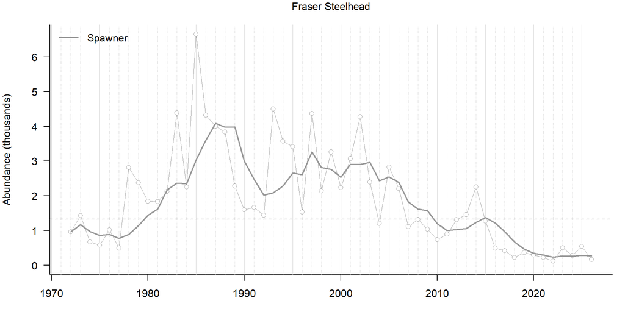

**Above:** Spawner abundance of Fraser steelhead salmon. The raw data is shown by points and the smoothed metric by solid lines. Dashed horizonal lines represent the long-term average.

```r
## Load data ---
# Use sum of two main Fraser steelhead CUs

frsh <- read.csv("https://raw.githubusercontent.com/salmonwatersheds/steelhead-data/refs/heads/main/output/dataset1_spawner-abundance_Steelhead.csv") %>%
    filter(region == "Fraser", species_name == "Steelhead") %>%
    filter(cu_name_pse %in% c("Thompson Summer", "Mid Fraser Summer")) %>%
    filter(!is.na(estimated_count) & estimated_count != -989898)

frsh_sum <- tapply(as.numeric(frsh$estimated_count), frsh$year, sum)
frsh_sum <- frsh_sum[min(which(!is.na(frsh_sum))): max(which(!is.na(frsh_sum)))]

# Put in SPS format
frsh_sps <- data.frame(
    region = rep("Fraser", length(frsh_sum)),
    species = rep("Steelhead", length(frsh_sum)),
    year = as.numeric(names(frsh_sum)),
    spawners = frsh_sum, # Note this is the fish that returned to spawn, NOT a mistake!
    smoothedSpawners = NA,
    runsize = NA,
    smoothedRunsize = NA,
    source_id = rep("Bison_20241129", length(frsh_sum))
)

# Smoothing
frsh_sps$smoothedSpawners <- genSmooth(
    abund = frsh_sps$spawners,
    years = frsh_sps$year,
    genLength = genLength$gen_length[genLength$region == "Fraser" & genLength$species == "Steelhead"]
)

# Add to master sps dataframe
sps_data <- rbind(sps_data, frsh_sps)

# Generate standard figure
plot_abund(frsh_sps)
```

### 2.2.10 Columbia

#### Chinook

We used CU-level estimates of spawner abundance (run reconstructions) sourced from DFO (Athena Ogden, pers. comm.) for 2006-2023 and Okanagan Nation Alliance (Katherine Fegan, pers. comm.) for 2024-2025.

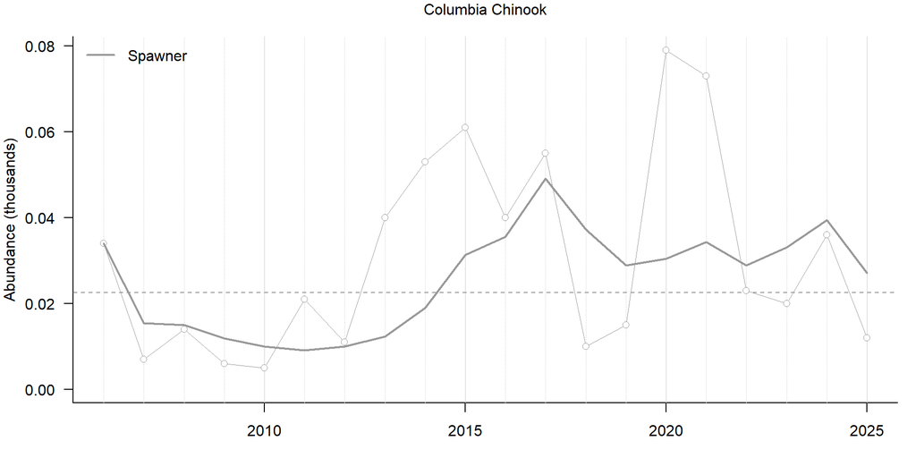

**Above:** Spawner abundance of Columbia chinook salmon. The raw data is shown by points and the smoothed metric by solid lines. Dashed horizonal lines represent the long-term average.

```r
colck <- read.csv(here("data/Chinook_Okanagan_NEW.csv")) %>% filter(Year >= 2006)
# Downloaded from https://github.com/SOLV-Code/Scanner-Data-Processing/blame/main/DATA_IN/Chinook_Okanagan_NEW.csv
# on March 18, 2025

# Put in SPS format
colck_sps <- data.frame(
    region = rep("Columbia", length(colck$Year)),
    species = rep("Chinook", length(colck$Year)),
    year = colck$Year,
    spawners = as.numeric(colck$NatOrigSpn + colck$HatchOrigSpn), # Note this is the fish that returned to spawn, NOT a mistake!
    smoothedSpawners = NA,
    runsize = NA,
    smoothedRunsize = NA,
    source_id = rep("DFO_20250318", length(colck$Year))
) %>%
    bind_rows(data.frame(
        region = rep("Columbia", 2),
    species = rep("Chinook", 2),
    year = 2024:2025,
    spawners = c(36, 12),
    source_id = rep("Fegan_20260827", 2)
    ))

# Smoothing
colck_sps$smoothedSpawners <- genSmooth(
    abund = colck_sps$spawners,
    years = colck_sps$year,
    genLength = genLength$gen_length[genLength$region == "Columbia" & genLength$species == "Chinook"]
)

# Add to master sps dataframe
sps_data <- rbind(sps_data, colck_sps)

# Generate standard figure
plot_abund(colck_sps)
```

#### Sockeye

We used CU-level estimates of spawner abundance (run reconstructions) sourced from DFO (Athena Ogden, pers. comm.) for Chinook and sockeye. Spawner abundance for Columbia sockeye was the sum of estimates for Osoyoos and, more recently, Skaha Lakes and were the most up-to-date estimates as of June 2025 (Athena Ogden, pers. comm.). Total abundance for sockeye was extracted from DFO’s 2024 Wild Salmon Policy assessment for Osoyoos sockeye (DFO 2024) from 1980-2023.

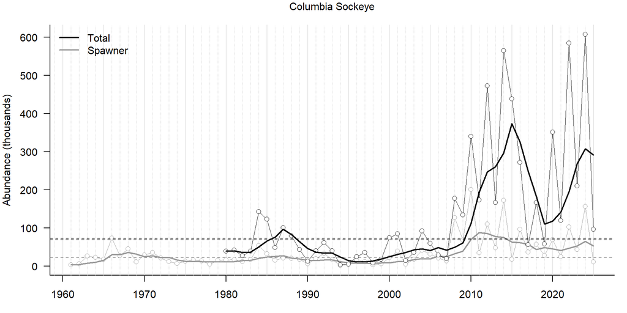

**Above:** Spawner abundance (grey) and total abundance (black) of Columbia sockeye salmon. For both, the raw data is shown by points and the smoothed metric by solid lines. Dashed horizonal lines represent the long-term average for each.

```r
# Load data ---
colse_old <- read.csv(here("data/spawner_abundance.csv")) %>%
    subset(region == "Columbia" &  species_name == "Lake sockeye") %>%
    subset(!is.na(estimated_count))

colse <- read.csv(here("data/OkanaganSockeye.csv"))

colse2 <- readxl::read_xlsx(here("data/Okanagan Sockeye Esc for KR_revJn2025.xlsx"), sheet = "CAN Escapement", range = "A1:E65")

# Put in SPS format
yrs <- c(sort(colse2$Year), 2025) # don't use pre-2004 (not comparable; DFO 2024)
colse_sps <- data.frame(
    region = rep("Columbia", length(yrs)),
    species = rep("Sockeye", length(yrs)),
    year = yrs,
    spawners = c(round(colse2$`Total spawners`[match(yrs[1:64], colse2$Year)]), 9440+1756), # 2025 numbers from Patrick Thompson email dated August 26 2026
    smoothedSpawners = NA,
    runsize = c(colse$runsize[match(yrs[1:63], colse$year)], 522231+85293, 81887+14907),
    smoothedRunsize = NA,
    source_id = c(rep("Ogden_20250627, Ogden_20250901", length(yrs) - 2), "Ogden_20250627, Thompson_20260826", "Thompson_20260826")
)

# Smoothing
colse_sps$smoothedSpawners <- genSmooth(
    abund = colse_sps$spawners,
    years = colse_sps$year,
    genLength = genLength$gen_length[genLength$region == "Columbia" & genLength$species == "Sockeye"]
)
colse_sps$smoothedRunsize <- genSmooth(
    abund = colse_sps$runsize,
    years = colse_sps$year,
    genLength = genLength$gen_length[genLength$region == "Columbia" & genLength$species == "Sockeye"]
)


# Add to master sps dataframe
sps_data <- rbind(sps_data, colse_sps)

# Generate standard figure
plot_abund(colse_sps)
```

#### Steelhead

There is no monitoring of steelhead trout in the Canadian portion of the Columbia region, but the Okanagan Nation Alliance does enumerate steelhead in akskwəkwant (Inkaneep Creek) and estimate a Canadian portion of steelhead spawning abundance. These data can be found in Table 8 of the associated report (e.g. OBMEP (2025)) and are available for the Mid Columbia Summer Conservation Unit [in the Pacific Salmon Explorer](https://salmonexplorer.ca/explore/data/spawner-abundance/columbia/steelhead/mid-columbia-summer-1380/).

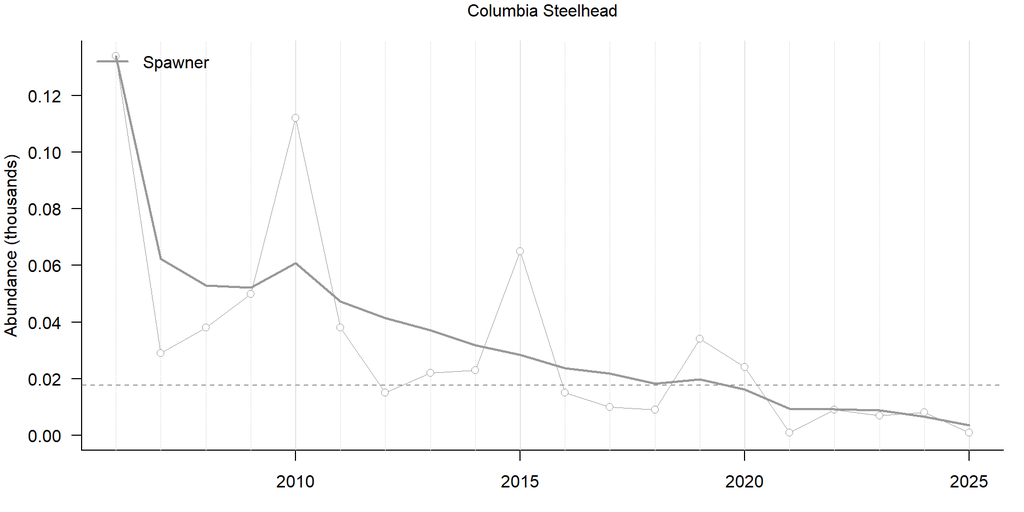

**Above:** Spawner abundance of Columbia steelhead salmon. The raw data is shown by points and the smoothed metric by solid lines. Dashed horizonal lines represent the long-term average.

```r
colsh <- read.csv(here("data/Columbia_Steelhead_OBMEP.csv"))

# Put in SPS format
colsh_sps <- data.frame(
    region = rep("Columbia", length(colsh$year)),
    species = rep("Steelhead", length(colsh$year)),
    year = colsh$year,
    spawners = colsh$natural_spawners, # Note this is the fish that returned to spawn, NOT a mistake!
    smoothedSpawners = NA,
    runsize = NA,
    smoothedRunsize = NA,
    source_id = rep("OBMEP_20260228", length(colsh$year))
)

# Smoothing
colsh_sps$smoothedSpawners <- genSmooth(
    abund = colsh_sps$spawners,
    years = colsh_sps$year,
    genLength = genLength$gen_length[genLength$region == "Columbia" & genLength$species == "Steelhead"]
)


# Add to master sps dataframe
sps_data <- rbind(sps_data, colsh_sps)

# Generate standard figure
plot_abund(colsh_sps)
```

```r
# Round abundances
sps_data$spawners <- round(sps_data$spawners)
sps_data$runsize <- round(sps_data$runsize)

sps_data$smoothedSpawners <- round(sps_data$smoothedSpawners, 1)
sps_data$smoothedRunsize <- round(sps_data$smoothedRunsize, 1)

write.csv(sps_data, here("output/sps-data.csv"), row.names = FALSE) # Always have most recent
write.csv(sps_data, paste0(Dropbox_dir, "/output/archive/", "sps-data_", Sys.Date(), ".csv"), row.names = FALSE) # Archive with date
```

## 2.3 Expansion Factors

For species and regions that lacked reliable data on spawner abundance and total return at the appropriate scale, we estimated regional-scale abundance from stream-level surveys. We started with spawner survey data shown in the [Pacific Salmon Explorer](https://www.salmonexplorer.ca). Spawner surveys were each assigned to one of the nine regions we considered based on their geographic location. We note that this is slightly different from how spawner survey data are organized in the Pacific Salmon Explorer, where data are organized by Conservation Units (CUs) that may span regional boundaries (e.g. for pink salmon that have relatively geographically large CUs). In cases of trans-regional CUs, the spawner surveys appear in both regions in the Pacific Salmon Explorer, whereas here we assign spawner surveys to the region in which they fall geographically, regardless of the CU boundary.

Spawner survey data are largely derived from river-level estimates in DFO’s [New Salmon Escapement Database System (NuSEDS)](https://open.canada.ca/data/en/dataset/c48669a3-045b-400d-b730-48aafe8c5ee6), but are cleaned up to address issues of, for example, inconsistent naming of streams through time or duplicate data. The spawner survey abundance is equal to the `MAX_ESTIMATE` in NUSEDS for each year and river population, calculated as the maximum of all fields containing spawner abundance data (e.g. natural adult spawners, natural jack spawners, total broodstock removals). Each of these river populations has been designated as an **indicator** stream or **non-indicator**. Indicator streams are observed more consistently in recent decades, tend to have higher spawner abundance, and tend to be monitored using more intensive methods that provide greater accuracy (English et al. 2018). We designate indicator streams based on the NuSEDS field with two exceptions: for regions in the north and central coast we relied on a review of indicator streams by English et al. (2016) and for WVI pink salmon we assigned indicator streams based on monitoring frequency (see Region Specific Data Sources: West Vancouver Island). The choice of indicator streams seemed to have minimal impact on results: outcomes did not change substantially when comparing between indicators designated by English et al. (2016) and in NuSEDS. Nonetheless, revisiting indicator designations is a priority in future years given ongoing declines in monitoring effort (Atkinson et al. 2025). For further information on the compilation of spawner survey data, see the [Pacific Salmon Explorer Technical Report](https://bookdown.org/salmonwatersheds/tech-report/analytical-approach.html#spawner-surveys).

Expansion Factor 1, $F_{1,y/d}$, expands the observed spawner abundances in indicator streams to account for indicator streams that are not monitored in a given year. It is calculated for each year $y$ of the spawner time series, and relies on a decadal contribution of each indicator stream to the total escapement to all indicator streams, $P_{d,i}$ in decade $d$ (English et al. 2018). The calculation of this decadal contribution requires at least one estimate from each indicator stream for the decade. If a decade does not contain sufficient information (i.e. one or more indicator streams are not monitored at all in a decade), then a reference decade is used to calculate $P_{d,i}$. This reference decade is chosen to be: (1) the closest decade (historical or future) with sufficient information, or failing (1), (2) the 20-year period from 1980-1999 (Challenger et al. 2018).

For each decade (or reference decade if insufficient information) $d$, the average number of spawners returning to indicator stream $i$ is calculated as:

$$\bar{S}_{d,i} = \sum_{y = 1}^{Y_{d,i}}
\frac{\hat{S}_{y/d, i}}{Y_{d,i}}$$
where $Y_{d,i}$ is the number of years for which spawner estimates are available within decade $d$ for stream $i$. From the average number of spawners for all indicator streams, the decadal proportional contribution of each indicator stream is calculated as:

$$P_{d,i} =
\frac{\bar{S}_{d,i}}{\sum_{i=1}^{I} \bar{S}_{d,i}}$$
where $I$ is the total number of indicator streams.

Expansion Factor 1 is then calculated for each year within the decade $y/d$ based on the decadal contributions and which streams were monitored or not in a given year:

$$F_{1,y/d}=\left( \sum_{i=1}^I P_{d,i}
w_{y/d,i} \right)$$
where $w_{y/d,i}$ is 1 if stream $i$ was monitored in year $y$ and 0 if stream $i$ was not monitored in year $y$. Expansion Factor 1 is then multiplied by the sum of the observed spawners in all indicator stream to yield the expanded estimate of spawner abundances in all indicator streams in the region:

$$S'_{y} = F_{1,y/d} \sum_{i=1}^I
\hat{S}_{y,i}$$

Expansion Factor 2 $F_{2,d}$ expands the spawner abundance to all indicator streams, $S'_{y}$, to account for non-indcator streams. Unlike Expansion Factor 1, this is calculated for each decade (rather than each year) and then applied to all years within a decade. Like Expansion Factor 1, there needs to be sufficient information within the given decade in order to calculate $F_{2,d}$, or else a reference decade is chosen. See English et al. (2018) for detailed on how reference decades are chosen in that case.

Expansion Factor 2 is calculated as:

$$F_{2,d} = \frac{\sum_{i = 1}^I
\bar{S}_{d,i} + \sum_{j = 1}^{J} \bar{S}_{d,j}}{\sum_{i = 1}^I
\bar{S}_{d,i}}$$
where $\bar{S}_{d,i}$ and $\bar{S}_{d,j}$ are the deacdal average number of spawners in indicator and non-indicator streams, respectively, calculated above. $J$ is the total number of non-indicator streams. The adjusted total number of spawners in both indicator and non-indicator streams is then calculated as:
$$S''_{y} = F_{2,d} S'_{y}$$

Note that when expanding spawner abundance for spawner-recruit analysis, a third expansion factor is applied to account for streams that are never monitored and for observer (in)efficiency (Peacock et al. 2020). We did not apply this third expansion factor because it is highly undertain and we are interested in relative changes in abundance through time, so we do not require to expand to absolute abundance.

## 2.4 Smoothing

We smoothed time series of spawner abundance and total return using a right-aligned running geometric mean over the length of a generation. This reduces the influence of dominant years and produces an index that is less sensitive to stochastic interannual variability that is common in salmon population dynamics. The generation length was based on the dominant life-history type for each species in a particular region. The smoothed spawner abundance in year $y$ given a generation length $g$ was calculated as:
$$\bar{S_{y}} = \left( \prod_{t = y-g+1}^y
{S''_t} \right)^{1/g}$$

We smoothed abundance from the first year to the most recent year of raw abundance data. If there were intermediate years with missing data, the smoothed abundance was still calculated using the available years (i.e. ignoring the missing data, with the exponent $1/g$ adjusted so that $g$ reflected the number of years with data in the generation). If all years in a generation were missing data, than the smoothed abundance was `NA`.

When plotting, we show the smoothed abundance relative to the long-term historical average, so that species that have vastly different abundances within a region can be plotted on the same y-axis for comparison.

## 2.5 Quantifying change

We summarize the time series of smoothed spawner abundance or total return at the regional scale using three different metrics:

1. **Current status** relative to historical average;
2. **Long-term trend** over the entire time series; and
3. **Short-term trend** over the most recent three generations.

The currents status provides information on how the most recent spawner abundance compares to past values, while the two trend metrics provide information on the average direction of change and are less sensitive to the magnitude of current abundance.

The **current status** relative to historical average is calculated as:
$$(\bar{S_{y}} - \bf{S}) /
\bf{S}$$
where $y$ is the most recent year for which the index of spawner abundance could be calculated and $\bf{S}$ is the average smoothed spawner abundance over the entire time series.

The **long-term trend** is calculated following the recommendations of D’Eon-Eggertson et al. (2015), who found that the correct identification of declines in salmon population abundance may be most reliable when considering the entire time series, and applying regression-based estimates of change calculated from log-transformed and smoothed spawner abundances. As such, we fit a simple linear model to the time series of $\log ( \bar{S}_{y} )$ over $y$. The resulting slope, $m$, gives an average estimate of annual change:

$$m = \log \left(
\frac{\bar{S}_{y}}{\bar{S}_{y-1}} \right)$$
.

With some rearranging, we can calculate the average annual percent change as:
$$\frac{\bar{S}_{y} -
\bar{S}_{y-1}}{\bar{S}_{y-1}} = \frac{ e^m \bar{S}_{y-1} -
\bar{S}_{y-1}}{\bar{S}_{y-1}} = e^m - 1$$
. If the slope $m$ is not significantly different from zero ($p \geq 0.05$), then the trend is classified as “stable” regardless of the magnitude of the estimated slope. If the slope is significantly different from zero ($p < 0.05$), then the trend is classified as increasing if $m > 0$ or decreasing if $m < 0$.

The **short-term trend** is calculated as described above, but only using the time series over the most recent three generations.

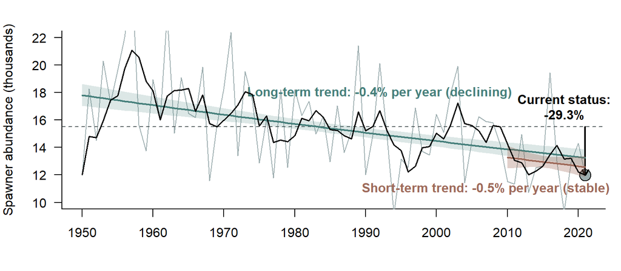

**Above:** Simulated time series of spawner abundance (grey line), smoothed with a running geometric mean over the generation length (4 years; black line). The three metrics are illustrated: **Current status** relative to historical average (black); **Long-term trend** over the entire time series (green); and **Short-term trend** over the most recent three generations (clay). The shaded regions of the regression lines indicate the 95% prediction intervals. In this example, the short-term trend is not statistically significant (p > 0.05), and so the trend is characterized as ‘stable’ despite the negative slope.

### 2.5.1 Additional Considerations

# 3 Results

**These are PRELIMINARY results and the following figures should not be taken as a statement on the status of salmon in these regions. Text “Highlights are LAST YEAR’S text.** At this time, we are working to verify datasets and refine our methods.

- These trends in aggregated spawner abundance provide a broad overview of how salmon are doing, but must be interpreted with caution due to the diversity of populations with potentially different outlooks within each region and species.
- The status of spawner abundance is, in most cases, more positive than the status in total return, highlighting that declines in fisheries have been pervasive.

**Highlights**

- Chum salmon have managed a comeback in some regions after being highlighted as one of the worst-off species in our 2024 report. In particular, chum spawner *and* total abundance in the **Nass** more than doubled from 2023 to 2024, though other regions (e.g., Yukon, Fraser) are still posting below-average current abundances.
- The Nass showed some of the most promising returns in 2024, with chum, coho, pink, and sockeye all above-average for spawner abundance and healthy catches for most species.
- Steelhead are still struggling, below average in all regions, though a lack of monitoring and reporting on their abundance makes it difficult to understand the extent of declines.

## 3.1 All regions

### Overview results table

**Below**: Summary of current status for **spawner or total abundance** (tabs) across regions and species, comparing between previous years’ outcomes and revised outcomes. Regions and species below historical average are in red and above historical average are in green. Black cells indicate species that are not thought to be present in the given region, and grey cells indicate status was Unknown. For some regions and species, numbers have changed even though the year is the same because (1) the long-term average is calculated from raw instead of smoothed abundances or (2) an updated or different data source was used.

#### Spawners

| Region | Year | State | Year | State | Year | State | Year | State | Year | State | Year | State |
| --- | --- | --- | --- | --- | --- | --- | --- | --- | --- | --- | --- | --- |
| Yukon | 2025 | -0.53392645255526 | 2025 | -0.739213375166611 | NA | NA | NA | -989898 | NA | -989898 | NA | -989898 |
| Yukon | 2024 | -0.495204337001744 | 2024 | -0.73598178480423 | NA | NA | NA | -989898 | NA | -989898 | NA | -989898 |
| Northern Transboundary | 2025 | -0.379106741476353 | 2025 | -0.442319557715732 | 2025 | -0.14098136932243 | 2025 | -0.663236455288674 | 2025 | 0.465451876670452 | 2025 | -0.188302678693844 |
| Northern Transboundary | 2024 | -0.462833016404266 | 2024 | -0.76177509579066 | 2024 | -0.13671135510224 | 2024 | -0.835093247927209 | 2024 | 0.342736345225399 | NA | NA |
| Haida Gwaii | 2025 | 0.108317343315335 | 2024 | -0.739730049682709 | 2024 | -0.77644256790858 | 2024 | 0.251635470857736 | 2024 | 0.142364036592367 | NA | NA |
| Haida Gwaii | 2006 | NA | 2023 | -0.668529442214711 | 2023 | -0.760015201039788 | 2023 | -0.295010502728605 | 2023 | -0.033908509978209 | NA | NA |
| Nass | 2025 | -0.0199951229882734 | 2025 | 0.9257370866364 | 2025 | 0.650636471946924 | 2025 | 4.38797076326662 | 2025 | 0.598308795382038 | 2025 | 0.0625610899760704 |
| Nass | 2024 | -0.162636021368165 | 2024 | 1.17676735589633 | 2024 | 0.743054514475919 | 2024 | 5.63809799014131 | 2024 | 0.486868627522675 | 2024 | -0.132883612530756 |
| Skeena | 2025 | -0.45138570098078 | 2024 | -0.835869294442563 | 2024 | -0.129825635651231 | 2024 | 2.93994057243737 | 2024 | 0.727974940817441 | 2025 | -0.436060024728066 |
| Skeena | 2024 | -0.504924104792379 | 2023 | -0.843678382325965 | 2023 | -0.0550250581824093 | 2023 | 2.36846786449471 | 2023 | 0.289856225108161 | 2024 | -0.405061553858767 |

[output cut: 10 more lines]

#### Runsize

| Region | Year | State | Year | State | Year | State | Year | State | Year | State | Year | State |
| --- | --- | --- | --- | --- | --- | --- | --- | --- | --- | --- | --- | --- |
| Yukon | 2025 | -0.735184918030284 | 2025 | -0.840036929432426 | NA | NA | NA | -989898 | NA | -989898 | NA | -989898 |
| Yukon | 2024 | -0.684713728016736 | 2024 | -0.846618335002545 | NA | NA | NA | -989898 | NA | -989898 | NA | -989898 |
| Northern Transboundary | 2025 | -0.452060948541617 | NA | NA | 2025 | -0.175864719695649 | NA | NA | 2025 | 0.035001325454053 | NA | NA |
| Northern Transboundary | 2024 | -0.529113849074763 | NA | NA | 2024 | -0.216432840188827 | NA | NA | 2024 | -0.114393983897957 | NA | NA |
| Haida Gwaii | NA | NA | NA | NA | NA | NA | NA | NA | NA | NA | NA | NA |
| Haida Gwaii | NA | NA | NA | NA | NA | NA | NA | NA | NA | NA | NA | NA |
| Nass | 2025 | -0.0581485867954825 | 2025 | 0.956833669041634 | 2025 | 0.446674596016005 | 2025 | 1.75628855606527 | 2025 | -0.0839019220650413 | 2025 | -0.0727400336915262 |
| Nass | 2024 | -0.105460870038381 | 2024 | 1.28689278681956 | 2024 | 0.533627021634148 | 2024 | 2.31898887659796 | 2024 | -0.180521626780691 | 2024 | -0.259427804783555 |
| Skeena | NA | NA | NA | NA | NA | NA | NA | NA | 2024 | 0.139537659497719 | NA | NA |
| Skeena | NA | NA | NA | NA | NA | NA | NA | NA | 2023 | -0.104374680933838 | NA | NA |

[output cut: 10 more lines]

## 3.2 Yukon

### 3.2.1 All species table

**Below:** Summary of the three metrics for spawners and total return. For long-term trends and short-term trends, the percentage is the average annual change calculated over the respective time period. Grey values indicate the % change was not significantly different from zero (i.e., stable), red values indicate declining trends, and green values indicate increasing trends.

| Species | Variable | Current status | Long-term trend | Short-term trend | Current | Previous generation | Historical average | Generation length | Years of data | Span of data |
| --- | --- | --- | --- | --- | --- | --- | --- | --- | --- | --- |
| Chinook | Spawners | -53.4% | -0.7% | -3.2% | 21,453 | 62,197 | 46,029 | 6 | 44 | 1982-2025 |
| Chinook | Total return | -73.5% | -3.5% | -5.9% | 24,775 | 82,521 | 93,555 | 6 | 44 | 1982-2025 |
| Chum | Spawners | -73.9% | +1.6% | -20.9% | 19,813 | 53,812 | 75,973 | 4 | 46 | 1980-2025 |
| Chum | Total return | -84% | -5.1% | -25% | 20,284 | 73,101 | 126,804 | 4 | 25 | 2001-2025 |
| Coho | Spawners |  |  |  | ? | ? | ? |  | 0 |  |
| Coho | Total return |  |  |  | ? | ? | ? |  | 0 |  |

### Chinook

#### Spawners

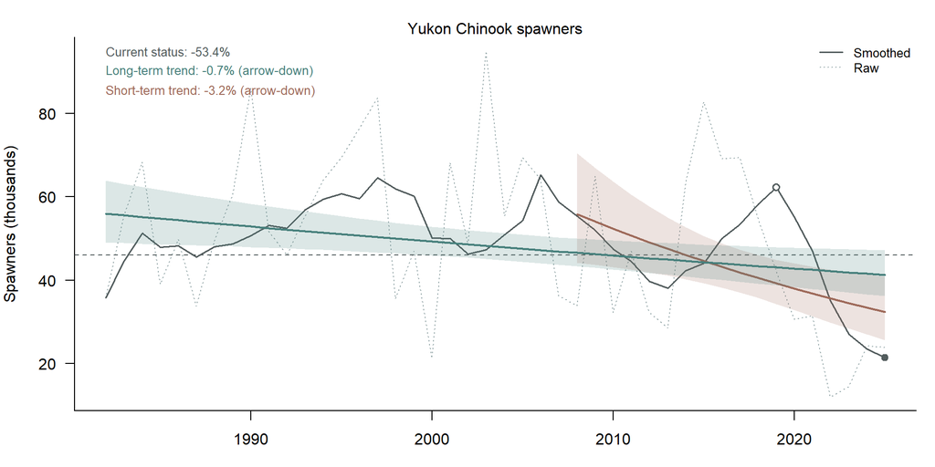

**Above:** Detailed status and trend metrics for Yukon Chinook: short-term (3-generation) and long-term trend lines with 95% confidence intervals, the long-term average (dashed line), and current status relative to that average.

#### Total Return

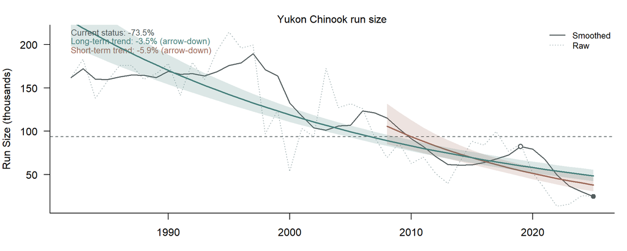

**Above:** Detailed status and trend metrics for Yukon Chinook: short-term (3-generation) and long-term trend lines with 95% confidence intervals, the long-term average (dashed line), and current status relative to that average.

### Chum

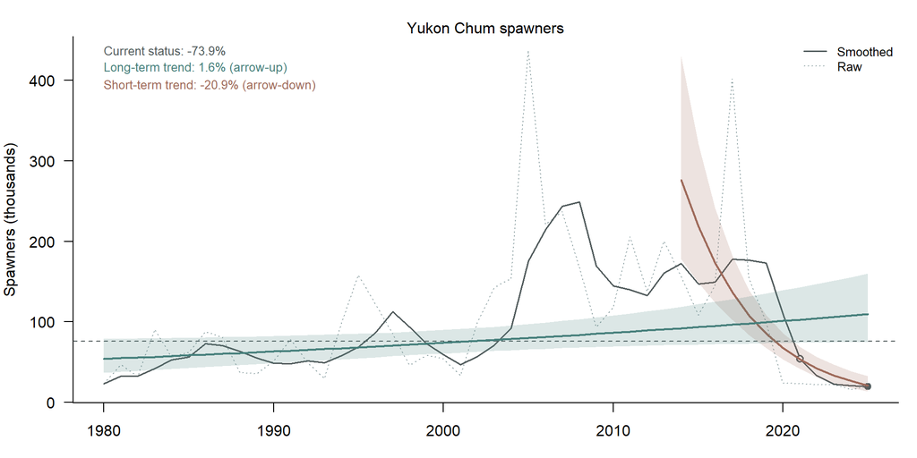

#### Total Return

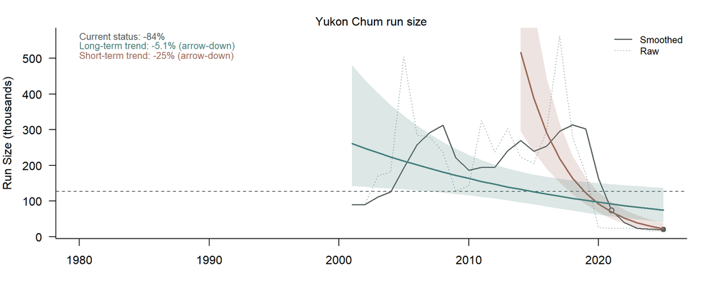

## 3.3 Northern Transboundary

**Highlights**

### 3.3.1 All species table

**Below:** Summary of the three metrics for spawners and total return. For long-term trends and short-term trends, the percentage is the average annual change calculated over the respective time period. Grey values indicate the % change was not significantly different from zero (i.e., stable), red values indicate declining trends, and green values indicate increasing trends.

| Species | Variable | Current status | Long-term trend | Short-term trend | Current | Previous generation | Historical average | Generation length | Years of data | Span of data |
| --- | --- | --- | --- | --- | --- | --- | --- | --- | --- | --- |
| Chinook | Spawners | -37.9% | -1.3% | -3.9% | 34,683 | 23,753 | 55,860 | 5 | 50 | 1976-2025 |
| Chinook | Total return | -45.2% | -1% | -6.5% | 37,748 | 28,412 | 68,892 | 5 | 50 | 1976-2025 |
| Chum | Spawners | -44.2% | -5% | -6% | 130 | 68 | 233 | 4 | 42 | 1984-2025 |
| Chum | Total return |  |  |  | ? | ? | ? | 4 | 0 |  |
| Coho | Spawners | -14.1% | +0.5% | -2.5% | 67,222 | 64,531 | 78,255 | 5 | 39 | 1987-2025 |
| Coho | Total return | -17.6% | -1.2% | -3% | 92,334 | 86,459 | 112,038 | 5 | 34 | 1992-2025 |
| Pink | Spawners | -66.3% | -2.7% | -28.3% | 3,015 | 7,046 | 8,953 | 2 | 42 | 1984-2025 |
| Pink | Total return |  |  |  | ? | ? | ? | 2 | 0 |  |
| Sockeye | Spawners | +46.5% | +0.5% | +2.5% | 206,440 | 132,378 | 140,871 | 5 | 42 | 1984-2025 |
| Sockeye | Total return | +3.5% | +0.2% | -1.3% | 330,835 | 257,579 | 319,647 | 5 | 42 | 1984-2025 |

[output cut: 2 more lines]

### Chinook

#### Spawners

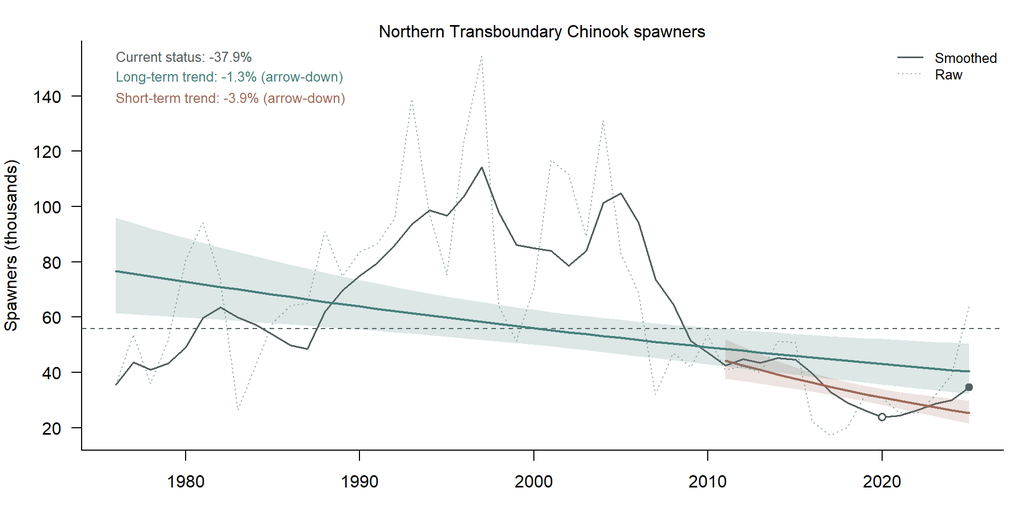

**Above:** Detailed status and trend metrics for Transboundary Chinook: short-term (3-generation) and long-term trend lines with 95% confidence intervals, the long-term average (dashed line), and current status relative to that average.

#### Total Return

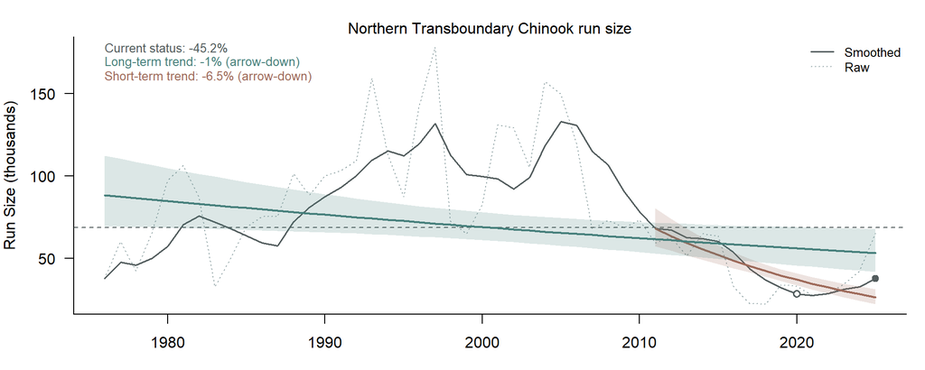

**Above:** Detailed status and trend metrics for Transboundary Chinook: short-term (3-generation) and long-term trend lines with 95% confidence intervals, the long-term average (dashed line), and current status relative to that average.

### Sockeye

#### Spawners

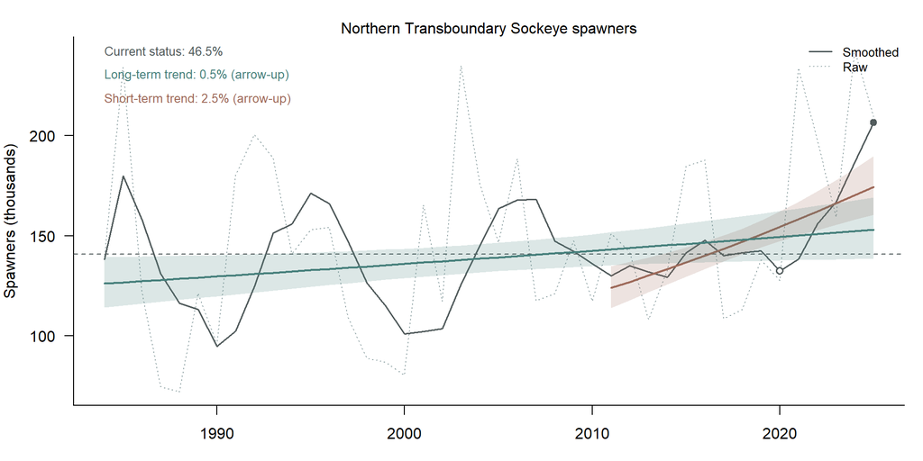

**Above:** Detailed status and trend metrics for Transboundary Sockeye: short-term (3-generation) and long-term trend lines with 95% confidence intervals, the long-term average (dashed line), and current status relative to that average.

#### Total Return

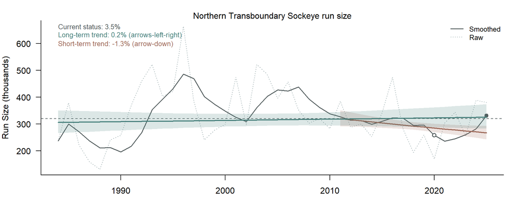

**Above:** Detailed status and trend metrics for Transboundary Sockeye: short-term (3-generation) and long-term trend lines with 95% confidence intervals, the long-term average (dashed line), and current status relative to that average.

### Coho

#### Spawners

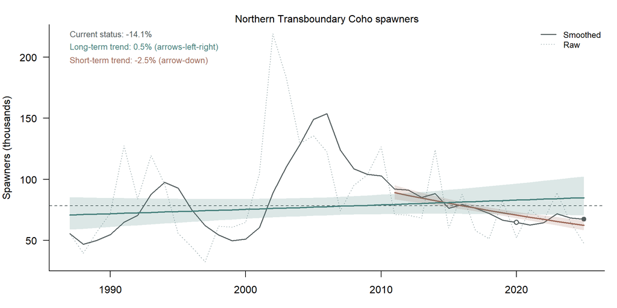

**Above:** Detailed status and trend metrics for Transboundary Coho: short-term (3-generation) and long-term trend lines with 95% confidence intervals, the long-term average (dashed line), and current status relative to that average.

#### Total Return

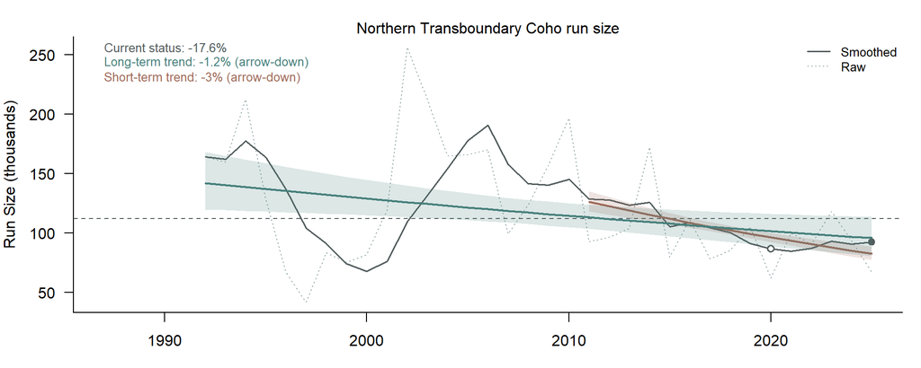

**Above:** Detailed status and trend metrics for Transboundary Coho: short-term (3-generation) and long-term trend lines with 95% confidence intervals, the long-term average (dashed line), and current status relative to that average.

### Chum

#### Spawners

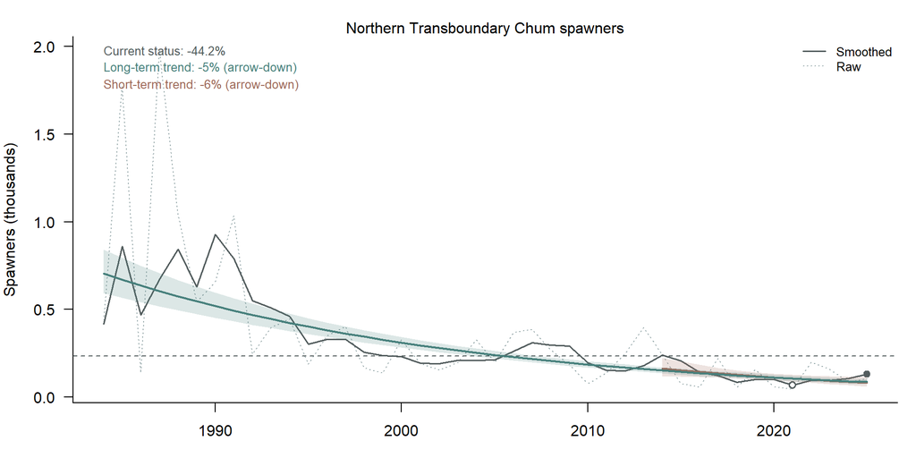

**Above:** Detailed status and trend metrics for Transboundary Chum: short-term (3-generation) and long-term trend lines with 95% confidence intervals, the long-term average (dashed line), and current status relative to that average.

### Pink

#### Spawners

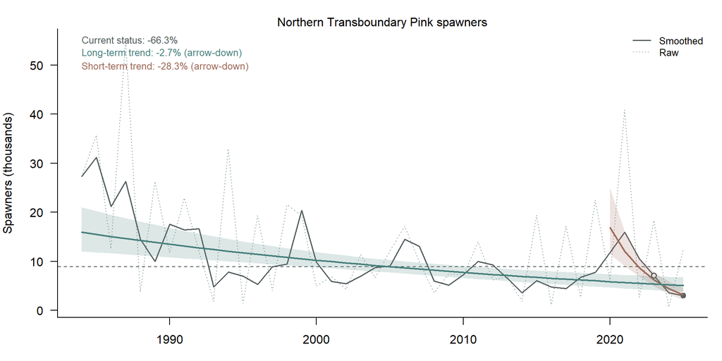

**Above:** Detailed status and trend metrics for Transboundary Pink: short-term (3-generation) and long-term trend lines with 95% confidence intervals, the long-term average (dashed line), and current status relative to that average.

### Steelhead

#### Spawners

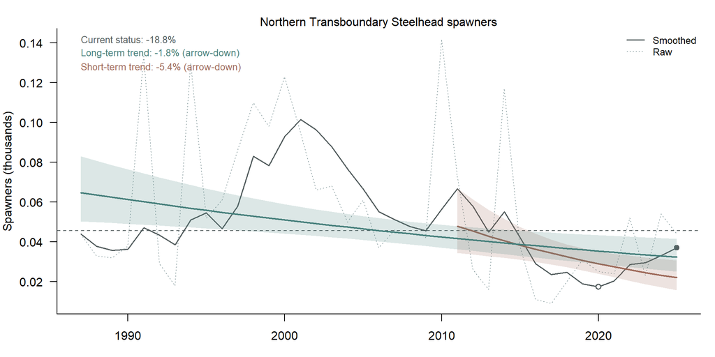

**Above:** Detailed status and trend metrics for Transboundary Steelhead: short-term (3-generation) and long-term trend lines with 95% confidence intervals, the long-term average (dashed line), and current status relative to that average.

## 3.4 Haida Gwaii

**Highlights**

### 3.4.1 All species table

**Below:** Summary of the three metrics for spawners and total return. For long-term trends and short-term trends, the percentage is the average annual change calculated over the respective time period. Grey values indicate the % change was not significantly different from zero (i.e., stable), red values indicate declining trends, and green values indicate increasing trends.

| Species | Variable | Current status | Long-term trend | Short-term trend | Current | Previous generation | Historical average | Generation length | Years of data | Span of data |
| --- | --- | --- | --- | --- | --- | --- | --- | --- | --- | --- |
| Chinook | Spawners | +10.8% | +0.6% | +11.9% | 1,800 | ? | 1,624 | 5 | 81 | 1935-2025 |
| Chinook | Total return |  |  |  | ? | ? | ? | 5 | 0 |  |
| Chum | Spawners | -74% | -1.8% | -7.2% | 67,251 | 160,386 | 258,388 | 5 | 75 | 1950-2024 |
| Chum | Total return |  |  |  | ? | ? | ? | 5 | 0 |  |
| Coho | Spawners | -77.6% | -1.2% | -13.7% | 16,894 | 53,013 | 75,571 | 4 | 75 | 1950-2024 |
| Coho | Total return |  |  |  | ? | ? | ? | 4 | 0 |  |
| Pink | Spawners | +25.2% | -0.4% | +2% | 425,554 | 143,224 | 339,998 | 2 | 75 | 1950-2024 |
| Pink | Total return |  |  |  | ? | ? | ? | 2 | 0 |  |
| Sockeye | Spawners | +14.2% | -0.5% | -1.4% | 40,249 | 32,785 | 35,233 | 5 | 75 | 1950-2024 |
| Sockeye | Total return |  |  |  | ? | ? | ? | 5 | 0 |  |

[output cut: 2 more lines]

### Chinook

#### Spawners

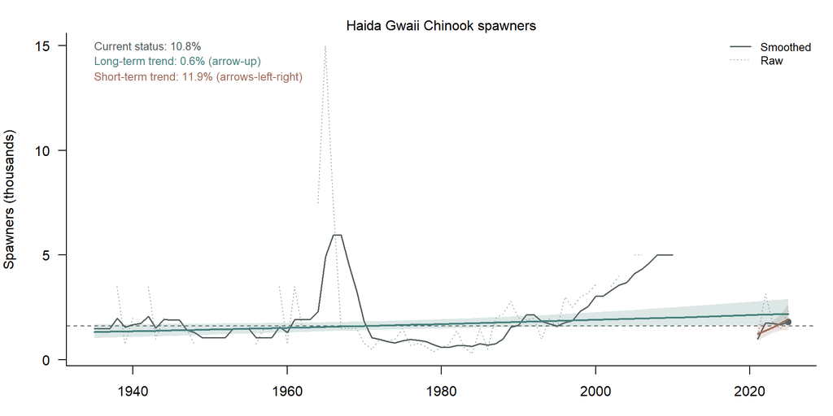

**Above:** Detailed status and trend metrics for Haida Gwaii Chinook: short-term (3-generation) and long-term trend lines with 95% confidence intervals, the long-term average (dashed line), and current status relative to that average.

### Chum

#### Spawners

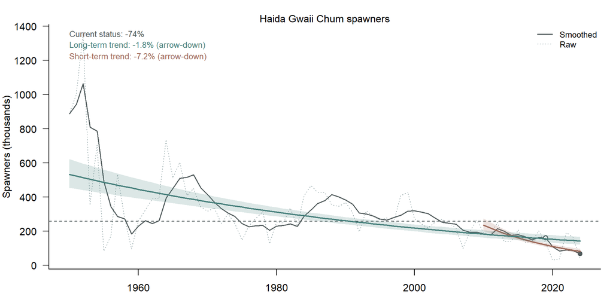

**Above:** Detailed status and trend metrics for Haida Gwaii Chum: short-term (3-generation) and long-term trend lines with 95% confidence intervals, the long-term average (dashed line), and current status relative to that average.